# Linear Algebra Chapter 1 Problems

Ryan Heslin

2021-08-26

```r
library(tidyverse)
library(matador)
```

# 1.1

Pre-multiplying by a permutation matrix switches rows, post-multiplying switches columns. Each 1 in the permutation “slices” every element of a row (in the first case, since the 1 cuts across the row margin), or a column (the second). Each column receives its own scalar because each column represents a variable - a mutable quantity that can take on just one value, but is assigned a scalar for each dimension (the numbers of the matrix, reading downward.)

So as a transformation a vector serves as a collection of scalars for variables, but itself contains only one variable able to be transformed.

$4\times{2}$

Say we are asked to find a system with the solutions:

$$x=6+5t\\
y=4+3t\\
z=2+t$$
Simply set up a matrix with the unknowns on the RHS and row reduce to eliminate the $t$ terms:

$$\begin{bmatrix}
t&2&z\\
3t&4&y\\
5t&6&x\end{bmatrix}$$

Row reduce:

$$\begin{bmatrix}
t&2&z\\
0&-2&y-3z\\
0&-4&x-5z\end{bmatrix}$$
Then zero out the last row as usual to get the last equation (the nullspace basis, as it happens:)

$$y-3z=-2\\
x-5z=-4\\
x-2y+z=0$$

## 21.

The three numbers whose sums in combinations of 2 are:

```r
A <- matrix(rep(1, 9), nrow =3)
diag(A) <- 0

solve(A, c(24, 28, 30))
```

```
## [1] 17 13 11
```

## 24.

The system’s solutions pass through (1,1,1) and (3,5,0). Since it is a line, one variable is free. The coefficients on $z$ are those that satisfy both points on the line setting $z$ at 1.
$$z\begin{bmatrix}3-2z\\5-4z\\z\end{bmatrix}$$

## 34.

Each output is the sum of the demand on each industry by each other industry plus the consumer demand. the system is:

$$\begin{align}
&x_1=.2x_2+.3x_3+320\\
&x_2=.1x_1+.4x_3+90\\
&x_3=.2x_1+.5x_2+150
\end{align}$$

```r
solve(a = matrix(c(1, -.2, -.3,
                   -.1,1, -.4,
                   -.2, -.5, 1), byrow = TRUE, nrow = 3),
      b = matrix(c(320, 90, 150)))
```

```
##      [,1]
## [1,]  500
## [2,]  300
## [3,]  400
```

## 35.

Polynomials of the form $8 + t -8t^2$

```r
solve(a = square(1, 1, 1, 1, 3, 9, 1, 1, 2),
      b = c(1, 3, 1))
```

```
## [1]  8  1 -8
```

## 37.

```r
solve(a = square(1, 1, 3, 2), b = c(1, 4))
```

```
## [1] 10 -3
```

## 45.

A system in three unknowns with solutions $(6+5t, 4 + 3t, 2 +t)$

$$\begin{aligned}
& 2x + y -z = 18 + 14 t\\
& x +y + z = 12 + 9t\\
& 3x -y + 2z = 16+ 14t
\end{aligned}$$
# 1.2

## 19.

All $4 \times 1$ RREFS are either $\begin{bmatrix}1\\0\\0\\0\end{bmatrix}$ or $\begin{bmatrix}0\\0\\0\\0\end{bmatrix}$. ## 20.

Given the RREF of

$$\begin{bmatrix}
0 & a & 2 &1 & b\\
0 & 0 &0 & c &d\\
0 & 0 & e & 0 &0
\end{bmatrix}$$
$a$ must be nonzero, $b$ is arbitrary, $c$ is 0, $e$ must be 0. $d$ is either 1 or 0; in the latter case so is $b$.

## 21.

Given the RREF of

$$\begin{bmatrix}
1 & a& b & 3 & 0 & -2\\
0 & 0 & c & 1 & d & 3\\
0 & e & 0 & 0 & 1 & 1
\end{bmatrix}$$

$e$ must be 0, $a$ and $b$ are arbitrary, though $b$ is 0 if $c$, also arbitrary, and $d$ must be 0.

## 32.

Finding a cubic: It turns out to be $a +2t -t^2 -2t^3$.

```r
A <- cbind(rep(1, 4),
           matrix(c(0, 0, 0, 1, 1, 1, -1, 1, -1, 2, 4, 8), nrow = 4, byrow = TRUE))
b <- c(1, 0, 0, -15)
solve(A, b)
```

```
## [1]  1  2 -1 -2
```

## 35.

Now for a derivative example. $f`(t) = b + 2ct +3dt^2$

It turns out to be $.625a - 1.0625bt + 1.25ct^2 + .1875dt^3$.

```r
A <- cbind(c(1, 1, 0, 0),
           matrix(c(1, 1, 1, 2, 4, 8, 1, 2, 3, 1, 4, 27), nrow = 4, byrow = TRUE))
b <- c(1, 5, 2, 9)
solve(A, b)
```

```
## [1]  0.6250 -1.0625  1.2500  0.1875
```

## 45.

We plug the given values into the formula for $t$ and use $S(t$ as the solution vector $b$. Then just solve the system:

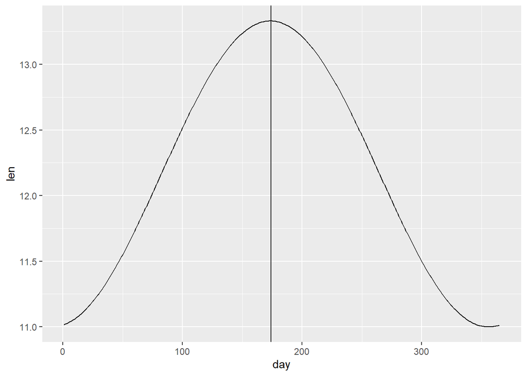

```r
library(tidyverse)
t <- c(47, 74, 273)
s_t <- matrix(c(11.5, 12, 12))
mat <- cbind(c(1,1,1),
             cos(((2*pi) * t ) / 365),
             sin(((2*pi) * t ) / 365))

coefs <- solve(a = mat, b= s_t)


days <- tibble( day = 1:365, len = coefs[1]+ (coefs[2] * cos((2*pi*1:365)/ 365)) + (coefs[3] * sin((2*pi*1:365)/ 365)))

ggplot(days, aes(day, len)) +
  geom_line() +
  geom_vline(aes(xintercept = day[which.max(len)]))
```

```r
max(days$len)
```

```
## [1] 13.33135
```

The longest day is about 13 hours long. ## 47.

Infintie: $k=2$ Inconsistent: $k= 1$ Otherwise: unique

## 48.

By row reducing the system to:

$$\begin{bmatrix}1&2&3&4\\
0&k-2&1&2\\
0&0&k-1&2\end{bmatrix}$$

## 66.

There were 120 liberals and 140 conservatives at the start, 140 and 120 respectively at the end.

```r
solve(matador::square(1, 1, 0, 0, -.3, -.6, 0, 1, -.7, -.4, 1, 0, 1, 0, 0, -1, byrow = TRUE), b = c(260, 0, 0, 0))
```

```
## [1] 120 140 140 120
```

## 74.

```r
((1500/19) -(15/19) *1:100)
```

```
##   [1] 78.1578947 77.3684211 76.5789474 75.7894737 75.0000000 74.2105263
##   [7] 73.4210526 72.6315789 71.8421053 71.0526316 70.2631579 69.4736842
##  [13] 68.6842105 67.8947368 67.1052632 66.3157895 65.5263158 64.7368421
##  [19] 63.9473684 63.1578947 62.3684211 61.5789474 60.7894737 60.0000000
##  [25] 59.2105263 58.4210526 57.6315789 56.8421053 56.0526316 55.2631579
##  [31] 54.4736842 53.6842105 52.8947368 52.1052632 51.3157895 50.5263158
##  [37] 49.7368421 48.9473684 48.1578947 47.3684211 46.5789474 45.7894737
##  [43] 45.0000000 44.2105263 43.4210526 42.6315789 41.8421053 41.0526316
##  [49] 40.2631579 39.4736842 38.6842105 37.8947368 37.1052632 36.3157895
##  [55] 35.5263158 34.7368421 33.9473684 33.1578947 32.3684211 31.5789474
##  [61] 30.7894737 30.0000000 29.2105263 28.4210526 27.6315789 26.8421053
##  [67] 26.0526316 25.2631579 24.4736842 23.6842105 22.8947368 22.1052632
##  [73] 21.3157895 20.5263158 19.7368421 18.9473684 18.1578947 17.3684211
##  [79] 16.5789474 15.7894737 15.0000000 14.2105263 13.4210526 12.6315789
##  [85] 11.8421053 11.0526316 10.2631579  9.4736842  8.6842105  7.8947368
##  [91]  7.1052632  6.3157895  5.5263158  4.7368421  3.9473684  3.1578947
##  [97]  2.3684211  1.5789474  0.7894737  0.0000000
```

```r
(400/19) - 1:100
```

```
##   [1]  20.05263158  19.05263158  18.05263158  17.05263158  16.05263158
##   [6]  15.05263158  14.05263158  13.05263158  12.05263158  11.05263158
##  [11]  10.05263158   9.05263158   8.05263158   7.05263158   6.05263158
##  [16]   5.05263158   4.05263158   3.05263158   2.05263158   1.05263158
##  [21]   0.05263158  -0.94736842  -1.94736842  -2.94736842  -3.94736842
##  [26]  -4.94736842  -5.94736842  -6.94736842  -7.94736842  -8.94736842
##  [31]  -9.94736842 -10.94736842 -11.94736842 -12.94736842 -13.94736842
##  [36] -14.94736842 -15.94736842 -16.94736842 -17.94736842 -18.94736842
##  [41] -19.94736842 -20.94736842 -21.94736842 -22.94736842 -23.94736842
##  [46] -24.94736842 -25.94736842 -26.94736842 -27.94736842 -28.94736842
##  [51] -29.94736842 -30.94736842 -31.94736842 -32.94736842 -33.94736842
##  [56] -34.94736842 -35.94736842 -36.94736842 -37.94736842 -38.94736842
##  [61] -39.94736842 -40.94736842 -41.94736842 -42.94736842 -43.94736842
##  [66] -44.94736842 -45.94736842 -46.94736842 -47.94736842 -48.94736842
##  [71] -49.94736842 -50.94736842 -51.94736842 -52.94736842 -53.94736842
##  [76] -54.94736842 -55.94736842 -56.94736842 -57.94736842 -58.94736842
##  [81] -59.94736842 -60.94736842 -61.94736842 -62.94736842 -63.94736842
##  [86] -64.94736842 -65.94736842 -66.94736842 -67.94736842 -68.94736842
##  [91] -69.94736842 -70.94736842 -71.94736842 -72.94736842 -73.94736842
##  [96] -74.94736842 -75.94736842 -76.94736842 -77.94736842 -78.94736842
```

15 sparrows, 6 ducks, 79 roosters.

## 50.

By row elimination and induction, we find the solution (where $k=n-1$) is $x_k =(1+n-k)x_n-x_{n+1}$

## 79.

They have 16, 12, and 8 coins, respectively.

```r
A <- matador::square(1, -2, -2,
                     -3, 1, -3,
                     -5, -5, 1)

solve(A, b = setNames(rep(-60, 3), 1:3))
```

```
## [1] 16 12  8
```

## 80.

```r
A <- matador::square(-1, 2, -3,
                     -4, 4, -7,
                     -2, 5, -3)
solve(A)
```

```
##            [,1]       [,2]        [,3]
## [1,]  1.3529412  0.1176471 -0.70588235
## [2,] -0.5294118 -0.1764706  0.05882353
## [3,] -0.1176471  0.2941176  0.23529412
```

# 1.3

## 29-32.

Let $x=\begin{bmatrix}5\\3\\-9\end{bmatrix}$ and $b=\begin{bmatrix}2\\0\\1\end{bmatrix}$. To find $A$ from these vectors, we just solve the system of equations
$$5a_1+3a_2-9a_3=b_n\\
a_1=\frac{b_2-3a_2-9a_3}{5}$$
substituting each element of $A$ for the corresponding row of $A$. The rank 1 $A$:

$$\begin{bmatrix}2/5&0&0\\
0&0&0\\
1/5&0&0\end{bmatrix}$$

All-nonzero $A$, by solving the equation above for each $b_n$ and subbing 1 for free variables,

$$A=\begin{bmatrix}5&1&1\\
6/5&1&1\\
7/5&1&1\end{bmatrix}$$

## 49.

Ranks given some information about matrices:

3x4 augment rank 2: rank 1 or 2. Partial row and column rank, so either no o infinitely many solutions.

3. $4\times{3}$, augment rank 4: no solution, since $b$ increases rank. $4\times{3}$ rank 3 has augment rank 3 or 4,d depending on whether $Ax=b$ has a solution. Partial row rank and full column rank, so either one or zero solutions.

3 x4, rank 3: augment rank 3, since full row rank guarantees a solution, so $AX=b$ for all $b$ Infinitely many solutions. ## Costs and Units

A system where the total number of items and their individual values and total value are known. Solutions are constrained to be integers (no fractional items).

For example, 32 $1, $5, and $10 bills worth $100 total. The system is:
$$x+y+z=32\\
x+5y+10z=100$$
Row reduce to get
$$x = 5/4z+15\\
y=17-9/4z$$

$$20/4+15+17-9/4+4=32\\
32=32$$

If the $\4\times{4}$ $Ax=b$ has a unique solution, then $Ax=c$ has either one or none, since the matrix has full row rank (for a unique solution) and therefor full column rank.

If $Ax=b$ is consistent, both column and row rank are partial, and $Ax=c$ has either one or infinite solutions.

if $A$ is $4\times{3}$ and $Ax=b$ has a unique solution, $Ax=c$ has either a unique solution or none. Rank is 3 (unique solution for 3 columns), but partial row rank does not guarantee solutions.

For rows, full rank means the guarantee of a solution; for columns, of a *unique* solution.

If $rank(A)=n$ and $m>n$, $m-n$ rows are zeroed. If $rank(A) = m$ and $n>m$, then $n-m$ free variables remain.

27. A rank-4 $4\times{4}$ has the identity as RREf.
28. A $5\times{3}$ matrix is 3, its RREF has two zeroed bottom rows.
29. Prove a tall matrix is always inconsistent for some $b$.  
    Since any $k>n$ vectors in $R^n$ are linearly dependent, an $m >n$ matrix has linearly dependent rows. Therefore each row can be expressed $r_i=c_1r_j+c_2r_k+\dotsc_nr_l$ Let $b_i$ be a linear combination of $b$ with different scalars such that $b_i\neq{c_1}b_j+c_2b_k+\dots{c_n}b_l$. Since $b$ and $A$ are independently determined, this is always possible.
30. Prove $A(kx) = k(Ax)$. Very easy. Referring to column vectors:

$$A(kx) = \begin{bmatrix}kv_1+kv_2+\dots kv_n\end{bmatrix}$$
$$k(Ax) = k\begin{bmatrix}kv_1+kv_2+\dots kv_n\end{bmatrix}=
\begin{bmatrix}kv_1+kv_2+\dots kv_n\end{bmatrix}$$

## 46.

Find the rank of
$$\begin{bmatrix}a&b&c\\
0&d&e\\
0&0&f\end{bmatrix}$$
assuming nonzero diagonal.

Rank is 3. Every row is a pivot row, so $b$, $c$, and $e$ can be eliminated, whatever they are, and the rows scaled to yield the identity. 47. If a system is homogeneous:

1. It is never inconsistent because $c_1r_1+c_2r_2+c_nr_n=0c_1+0c_2+0c_n$. No matter what LC reduces rows to 0, all LCs of the zero vector are 0.
2. A consistent partial column rank matrix always has solutions. Since homogeneous systems are always consistent.
3. $x_1+x_2=0+0$. If the equation has nullspace (and therefore infinitely many solutions), any LC of a given $x$ is a solution.
4. True also of $Ax=0\rightarrow{Akx=0}$
48. 1. In general, if $x_a$ and $x_b$ lie in the nullspace, then $x_a+x_b$ does as well, since the nullspace contains all LC’s of the basis vectors.
2. Also, if $x_b=x_a$, then we have $A0=0$
3. $\begin{bmatrix}x_1-x_2//0\end{bmatrix}$. The dependent row is zeroed.
35. $A_e_i$. The identity matrix copies each input at its position
36. $A$ 4x3, augment has rank 4. There are is a unique solution because adding $b$ increases the rank, so no linear dependency is created.
37. For $m\times{n}$ A and $r\times{s}$, and $x$ in $R^p$, $A(Bx)$ is defined if $s =p$ and $n=r$, since $Bx$ has $B's rows$
38. If two $R^3$ vectors are nonparallel, they span $c_1v_1+c_2v_2$ for all real $c$. They always span the zero vector, and span either a line or plane, depending on linear dependency.

## 52.

Just multiply them together.

## 54.

Two nonparallel vectors in $R^3$ describe a plane.

## 57.

To get a vector as an LC of two lines, pick vectors on the lines and solve:

```r
solve(a = matrix(c(1, 3, 2, 1), nrow = 2), b = matrix(c(7,11)))
```

```
##      [,1]
## [1,]    3
## [2,]    2
```

## 59.

```r
matrix(c(rep(1, 4), 1:4), nrow = 4) %*% matrix(c(3, 2))
```

```
##      [,1]
## [1,]    5
## [2,]    7
## [3,]    9
## [4,]   11
```

## 63.

All vectors of the form $v +cw$ are shears - distortions that add some scalar of one vector to another, such that the origianl vector remaisn at the center. Assuming this order, vertical shears.

## 65.

Transformations of the form $av+ bw$ are dual shears, both horizontal and vertical.

## 66.

Transformations of this form where $a +b =1$ are projections of positive portions of $v$ and $w$ onto one another.

## 67.

If we add the constraint $a +b=$, we have rotations.

## 68.

$u \cdot v =u \cdot w$ for all vectors $u$ that bisect $v$ and $w$ and have half the length(I think)
$$u_1(v_1 - w_2) = u_2(v_2 - w_2)$$

# True or False?

1. True; $Ax$ is a linear combination of the columns and $x$.
2. True also for vectors.
3. True; no more rows can be eliminated.

4 False; a $4\times{3}$ system is consistent for $x=0$ at least.

5. False; no $3\times{4}$ matrix can have rank above 3.
6. True; the the product has dimension of the LHS.
7. False; many square matrices are not one-to-one.
8. False; a system only ever has zero, one, or infinite solutions.
9. False; a $rank <m$ matrix always has null space beyond the zero vector because it has at least one free variables.
10. False; columns of free variables are not reduced to ones.
11. True; a row of zeroes equal to anything besides 0 always means inconsistency.
12. True; in general, a diagonal matrix can be found for any $b$ given any $x$ that just scales each element appropriately.
13. True, assuming $a\neq{b}$
14. True; these vectors are linearly independent.
15. False. It could be something like:

$$\begin{bmatrix}
0&0&0\\
0&0&0\\
0&0&0\\
0&0&1\end{bmatrix}$$

16. False. $kAx=A(kx)$, so if $Ax=\begin{bmatrix}1\\2\end{bmatrix}$, then $A(2x)$ should be $\begin{bmatrix}2\\4\end{bmatrix}$, not $\begin{bmatrix}2\\1\end{bmatrix}$.
17. False. All linear combinations of linearly dependent vectors are themselves linearly dependent.
18. False; a matrix consisting only of one value only ever has rank one.
19. False. The product has two dimensions.

```r
matrix(c(11, 17,13,19, 15, 21), nrow = 2) %*% matrix(c(-1, 3, -1))
```

```
##      [,1]
## [1,]   13
## [2,]   19
```

20. True; $x_1=2$ and $x_2=1$.
21. True. One such matrix is:

$$\begin{bmatrix}-1&1\\
-3&1\\
-5&1\end{bmatrix}$$

$$c_1v+c_2w=u\\
c_2w = u-c_1v\\
w = \frac{u-c_1v}{c_2}$$

36. True. The values in a free variable’s column represent that column as a linear combination of the other column vectors.
37. Obviously false. Adding two rank-3 $3\times{3}$s will not give you a rank 6!
38. False. Row ops can do anything except create leading entries, so as long as rank is the same, any two full-rank square matrices can be so converted. But a permutation of columns (e.g., ones) would make this impossible.
39. True. By linearity:

$$v=c_1u+c_2w\\
A(v)=A(c_1u+c_2w)=c_1Au+c_2Aw$$

```r
tests <- replicate(n = 500, matrix(sample(0:1, 9, replace = TRUE), nrow = 3), simplify = FALSE) %>%
  suppressWarnings(map(~try(solve(.x)))) %>%
  map_lgl(is.matrix) %>%
  sum()
tests
```

```
## [1] 500
```